# BBDC - Final Code

AE

10/15/2019

# Bremen Big Data Challenge

The challenge given to contestants was to take wind farm data collected from January, 2016 to June 2017, and the predict the wind farm’s output in July - December of 2017.

The data includes:

- Wind speed and direction at different elevations (All measurements were collected at various heights. All measurements were only taken at certain intervals, and as such certain observations have been linearly interpolated.)
- A boolean variable which reflects whether the given observation was interpolated or not
- Capacity of the farm at a given time (This capacity variable is very nearly constant, and most likely only shows variation due to maitainence or downages at the farm.)
- Output of the farm (The original “challenge” data set presented to the contestants did not have any values in the output variable. Outside of the voiding of the output column, the challenge set and validation set are identical.)

Contestants were meant to predict the output of the farm, input the values into the data frame, and upload a CSV file to the contest website, which would then calculate the percentage error without revealing any data to the contestants. I contacted the BBDC staff after the conclusion of the contest to acquire the validation set, such that I could continue my analysis. Absolutely no models in this analysis were in any way trained on the validation set. This set is used exclusively to create predictions, and to calculate the error percentages of the models within the scope of this file, rather than through the contest website. The formulas used to calculate the error are as were given on the contest website.

### Libraries

```r
library(foreign)
library(MASS)
library(car)
```

```r
library(corrplot)
library(rpart) #for trees
library(ipred) #for bagging
library(randomForest) #for random forest
library(readr) #read in data
library(gbm) #for gradient boosting
library(rms)
library(gam)
library(ISLR)
library(caTools)
library(circular)
library(openair)
```

```r
set.seed(101)
```

### Methods

```r
##########Methods##############
# some functions which are handy for plotting heatmaps of correlation matrices
#
# Get lower triangle of the correlation matrix
get_lower_tri<-function(cormat){
  cormat[upper.tri(cormat)] <- NA
  return(cormat)
}
# Get upper triangle of the correlation matrix
get_upper_tri <- function(cormat){
  cormat[lower.tri(cormat)]<- NA
  return(cormat)
}
reorder_cormat <- function(cormat){
  # Use correlation between variables as distance
  dd <- as.dist((1-cormat)/2)
  hc <- hclust(dd)
  cormat <-cormat[hc$order, hc$order]
}
####
```

### Data Import and Preprocessing

```r
#Training Data
train <- read_csv("Data/train.csv")
View(train)
summary(train)
sum(is.na(train)) #No missings

#Reviewing the date variable
class(train$Datum)
#Altering the location, so info is saved in English
Sys.setlocale("LC_ALL", "en_US.UTF-8")
#converting to date format
train$Datum <- as.Date(train$Datum, format = c("%Y-%m-%d"))

#Saving a copy of the training set without date
Train.nodate <- train[,-1]

#Validation Data
eval <- read_csv("Data/eval.csv")
View(eval)
summary(eval)
sum(is.na(eval)) #no missings

#Converting the validation set to a dataframe
class(eval)
eval <- as.data.frame(eval)

#converting date variable to type date
class(eval$Datum)
eval$Datum <- as.Date(eval$Datum, format = c("%Y-%m-%d"))
```

The output of the turbines is capped at 122400, so the output should not exceed this value. Below I review the two data frames to make sure there are no max value anomolies.

```r
max(train$Output)
```

```
## [1] 120520
```

```r
max(eval$Output)
```

```
## [1] 120460
```

Since neither data frame has output values which exceed the maxium, I don’t need to cap any values.

### Reviewing the Variable Distributions

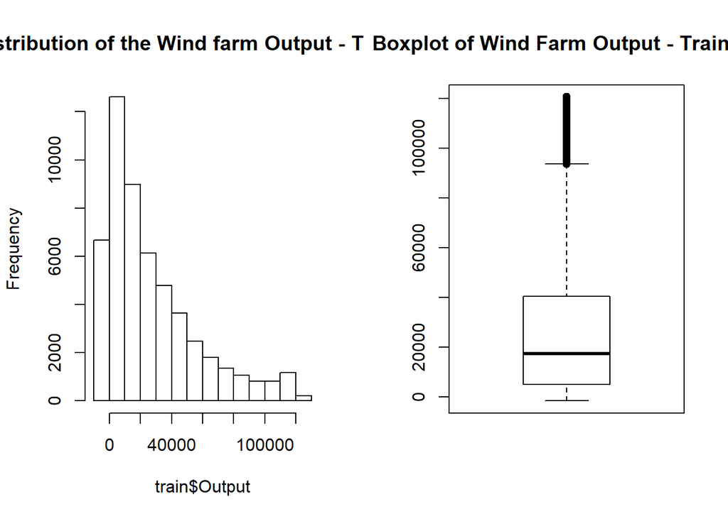

```r
#Distribution of Numeric Training Variables

##Output - Training
par(mfrow = c(1, 2))
hist(train$Output, main = "Distribution of the Wind farm Output - Training")
boxplot(train$Output, main = "Boxplot of Wind Farm Output - Training")
```

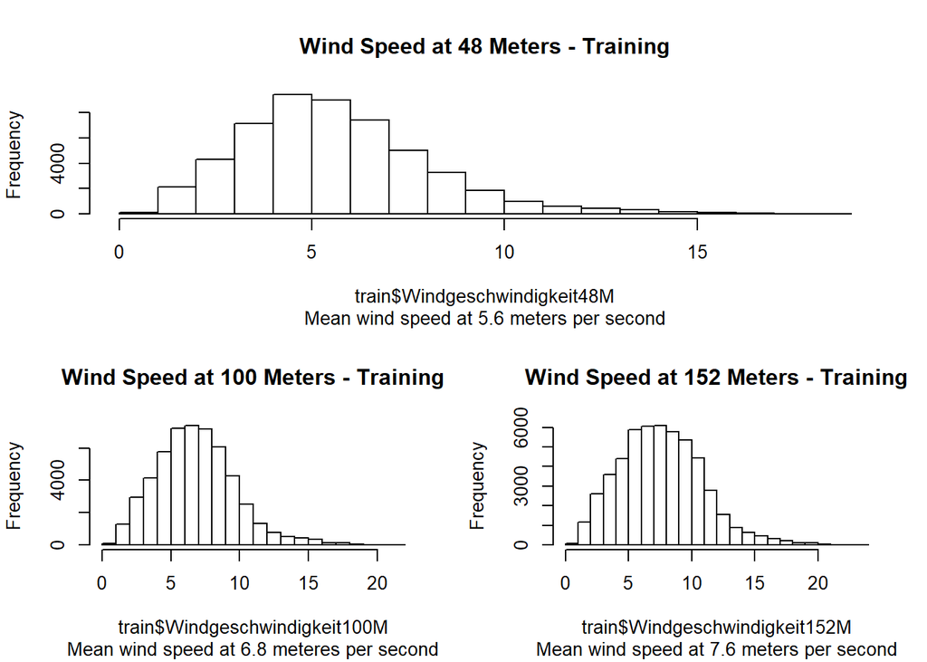

```r
##Wind Strength - Training
layout(matrix(c(1,1,2,3), 2, 2, byrow = TRUE))
hist(train$Windgeschwindigkeit48M, main = "Wind Speed at 48 Meters - Training", sub = "Mean wind speed at 5.6 meters per second")
hist(train$Windgeschwindigkeit100M, main = "Wind Speed at 100 Meters - Training", sub = "Mean wind speed at 6.8 meteres per second")
hist(train$Windgeschwindigkeit152M, main = "Wind Speed at 152 Meters - Training", sub = "Mean wind speed at 7.6 meters per second")
```

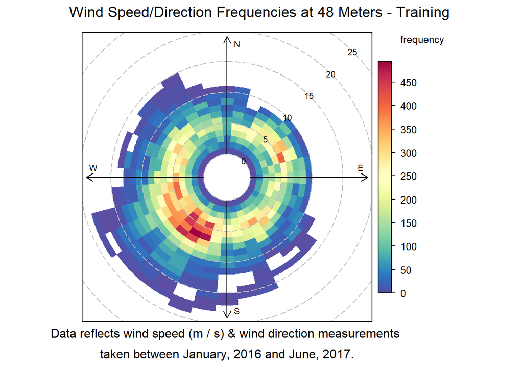

```r
##Wind speed/direction frequency - training
###At 48M
####Creating dataframe of wind speed, wind direction, and date (converting wind direction to circular object with degree units)
df_48 <- data.frame(train$Windgeschwindigkeit48M, circular(train$Windrichtung48M, units = "degrees"), train$Datum)
names(df_48) <- c("ws", "wd", "date")
####frequency plot
polarFreq(df_48, main = "Wind Speed/Direction Frequencies at 48 Meters - Training", xlab = "Data reflects wind speed (m / s) & wind direction measurements \n taken between January, 2016 and June, 2017.", trans = FALSE)
```

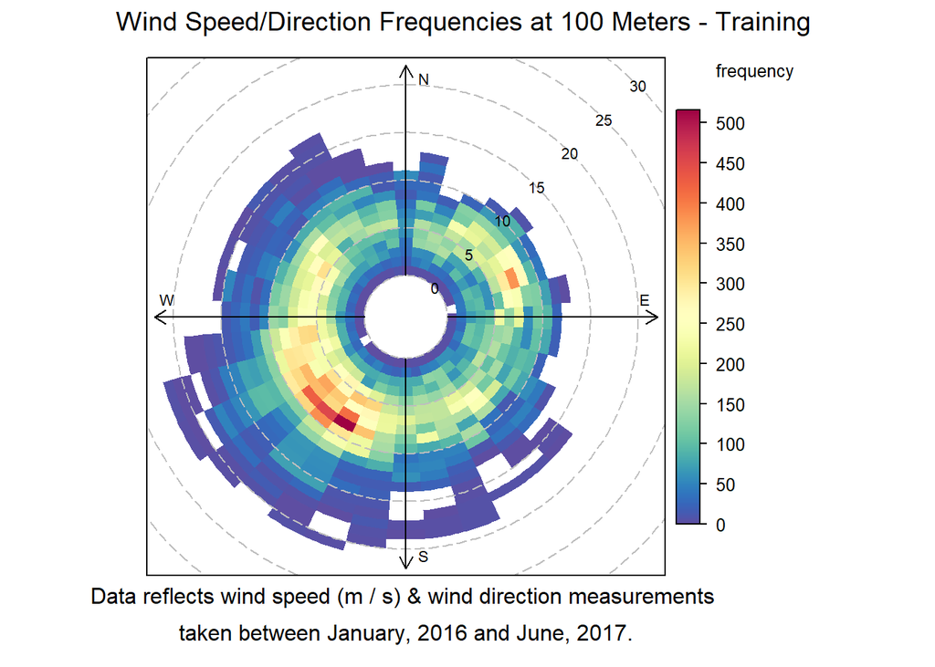

```r
###At 100M
####Creating dataframe of wind speed, wind direction, and date (converting wind direction to circular object with degree units)
df_100 <- data.frame(train$Windgeschwindigkeit100M, circular(train$Windrichtung100M, units = "degrees"), train$Datum)
names(df_100) <- c("ws", "wd", "date")
####frequency plot
polarFreq(df_100, main = "Wind Speed/Direction Frequencies at 100 Meters - Training", xlab = "Data reflects wind speed (m / s) & wind direction measurements \n taken between January, 2016 and June, 2017.", trans = FALSE)
```

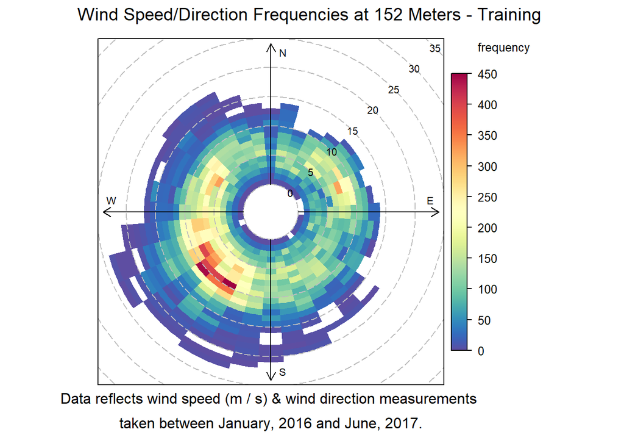

```r
###At 152M
####Creating dataframe of wind speed, wind direction, and date (converting wind direction to circular object with degree units)
df_152 <- data.frame(train$Windgeschwindigkeit152M, circular(train$Windrichtung152M, units = "degrees"), train$Datum)
names(df_152) <- c("ws", "wd", "date")
####frequency plot
polarFreq(df_152, main = "Wind Speed/Direction Frequencies at 152 Meters - Training", xlab = "Data reflects wind speed (m / s) & wind direction measurements \n taken between January, 2016 and June, 2017.", trans = FALSE)
```

The above three plots show, in order of increase height measurement level, the frequency of speed and directional wind measurments. For all three height levels, the majority of winds were blowing in a south-westernly direction at a speed between 5 and 10 meters per second.

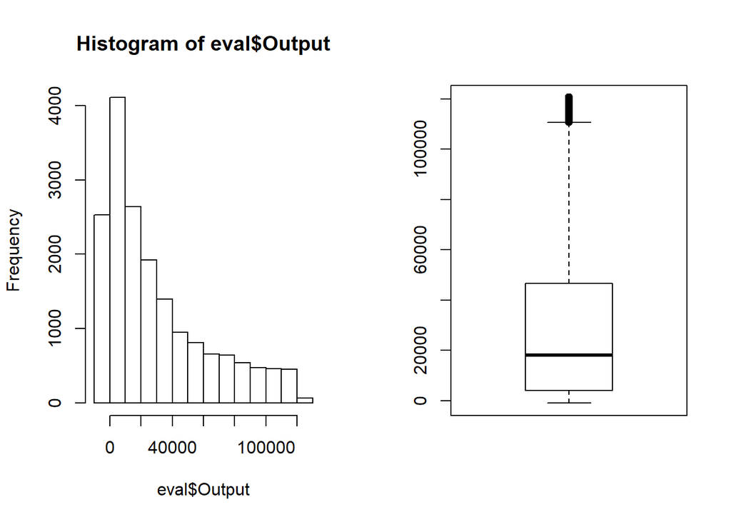

```r
#Distribution of Numeric Validation Variables

##Output - Validation
par(mfrow = c(1, 2))
#title("Distribution of the Wind farm Output - Validation")
hist(eval$Output)
boxplot(eval$Output)
```

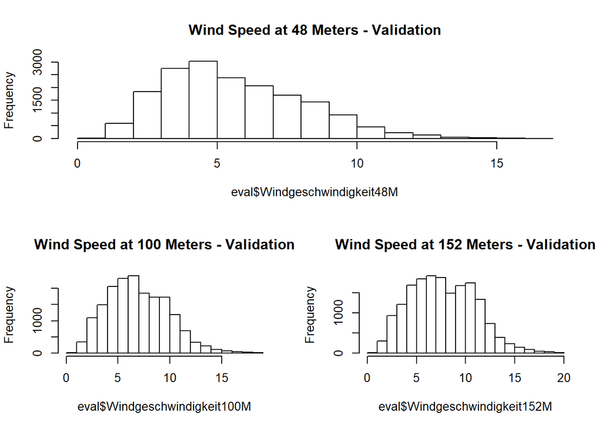

```r
##Wind Speed - Validation
layout(matrix(c(1,1,2,3), 2, 2, byrow = TRUE))
hist(eval$Windgeschwindigkeit48M, main = "Wind Speed at 48 Meters - Validation")
hist(eval$Windgeschwindigkeit100M, main = "Wind Speed at 100 Meters - Validation")
hist(eval$Windgeschwindigkeit152M, main = "Wind Speed at 152 Meters - Validation")
```

Unlike the training data, which showed relatively normal distributionsfor the wind speeds, these distributoins are slightly less so. Specifically, the speeds measured at the 152 metter height level appear to be bimodal, with local maxima at approximately 7 m/s and 11 m/s.

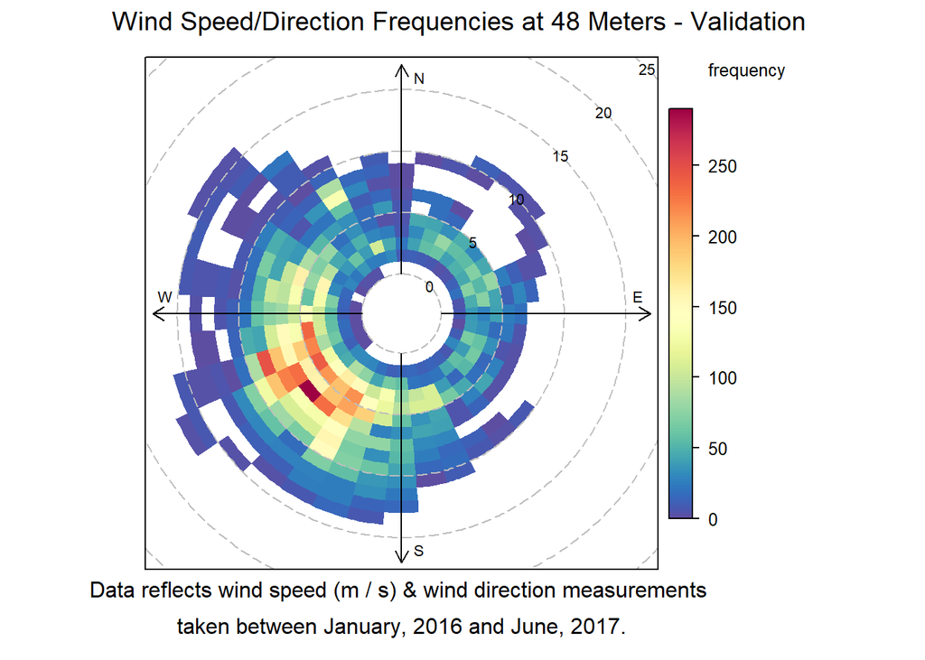

```r
##Wind speed/direction frequency - Validation

###At 48M
####Creating dataframe of wind speed, wind direction, and date (converting wind direction to circular object with degree units)
df_48 <- data.frame(eval$Windgeschwindigkeit48M, circular(eval$Windrichtung48M, units = "degrees"), eval$Datum)
names(df_48) <- c("ws", "wd", "date")

####frequency plot
polarFreq(df_48, main = "Wind Speed/Direction Frequencies at 48 Meters - Validation", xlab = "Data reflects wind speed (m / s) & wind direction measurements \n taken between January, 2016 and June, 2017.", trans = FALSE)
```

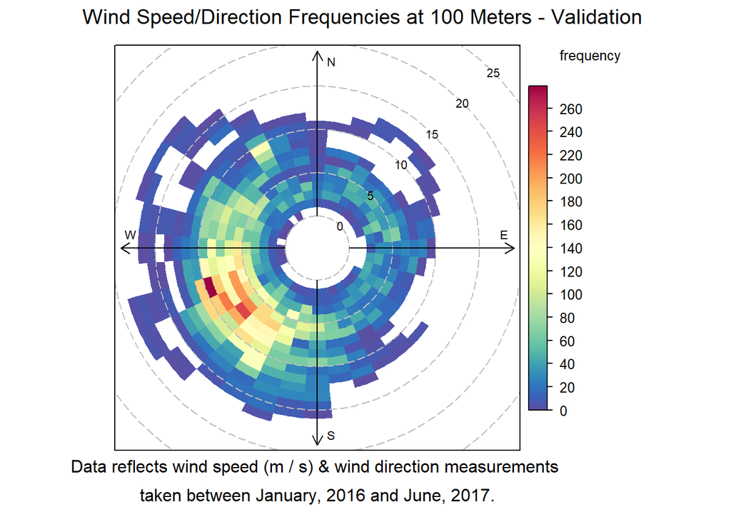

```r
###At 100M
####Creating dataframe of wind speed, wind direction, and date (converting wind direction to circular object with degree units)
df_100 <- data.frame(eval$Windgeschwindigkeit100M, circular(eval$Windrichtung100M, units = "degrees"), eval$Datum)
names(df_100) <- c("ws", "wd", "date")
####frequency plot
polarFreq(df_100, main = "Wind Speed/Direction Frequencies at 100 Meters - Validation", xlab = "Data reflects wind speed (m / s) & wind direction measurements \n taken between January, 2016 and June, 2017.", trans = FALSE)
```

[figure not shown]

```r
###At 152M
####Creating dataframe of wind speed, wind direction, and date (converting wind direction to circular object with degree units)
df_152 <- data.frame(train$Windgeschwindigkeit152M, circular(train$Windrichtung152M, units = "degrees"), train$Datum)
names(df_152) <- c("ws", "wd", "date")
####frequency plot
polarFreq(df_152, main = "Wind Speed/Direction Frequencies at 152 Meters - Validation", xlab = "Data reflects wind speed (m / s) & wind direction measurements \n taken between January, 2016 and June, 2017.", trans = FALSE)
```

### Data Manipulation, Feature Creation, and Spliting the Training Data

```r
split <- sample.split(train$Output,
                      SplitRatio = .70)
train1 <- subset(train, split == TRUE)
test <- subset(train, split == FALSE)

#Adding Variables for Analysis
#Adding month variable
train$month <- months(train$Datum)
train$season <- 0
train$season[train$month == "May"] = 1
train$season[train$month == "June"] = 1
train$season[train$month == "July"] = 1
train$season[train$month == "August"] = 1
train$season[train$month == "September"] = 1
train$season[train$month == "October"] = 1

train$month[train$month == "January"] = 1
train$month[train$month == "February"] = 2
train$month[train$month == "March"] = 3
train$month[train$month == "April"] = 4
train$month[train$month == "May"] = 5
train$month[train$month == "June"] = 6
train$month[train$month == "July"] = 7
train$month[train$month == "August"] = 8
train$month[train$month == "September"] = 9
train$month[train$month == "October"] = 10
train$month[train$month == "November"] = 11
train$month[train$month == "December"] = 12
train$month <- as.numeric(train$month)

eval$month <- months(eval[,1])
eval$season <- 0
eval$season[eval$month == "May"] = 1
eval$season[eval$month == "June"] = 1
eval$season[eval$month == "July"] = 1
eval$season[eval$month == "August"] = 1
eval$season[eval$month == "September"] = 1
eval$season[eval$month == "October"] = 1

eval$month[eval$month == "January"] = 1
eval$month[eval$month == "February"] = 2
eval$month[eval$month == "March"] = 3
eval$month[eval$month == "April"] = 4
eval$month[eval$month == "May"] = 5
eval$month[eval$month == "June"] = 6
eval$month[eval$month == "July"] = 7
eval$month[eval$month == "August"] = 8
eval$month[eval$month == "September"] = 9
eval$month[eval$month == "October"] = 10
eval$month[eval$month == "November"] = 11
eval$month[eval$month == "December"] = 12
eval$month <- as.numeric(eval$month)

#Descriptives for the wind direction and speed
train$winddirectionmean <- ((train$Windrichtung48M+train$Windrichtung100M+train$Windrichtung152M)/3)
train$winddirectionvar <- (((train$Windrichtung48M-train$winddirectionmean)^2+(train$Windrichtung100M-train$winddirectionmean)^2+(train$Windrichtung152M-train$winddirectionmean)^2)/3)
train$windspeedmean <- ((train$Windgeschwindigkeit48M+train$Windgeschwindigkeit100M+train$Windgeschwindigkeit152M)/3)
train$windspeedvar <- (((train$Windgeschwindigkeit48M-train$windspeedmean)^2+(train$Windgeschwindigkeit100M-train$windspeedmean)^2+(train$Windgeschwindigkeit152M-train$windspeedmean)^2)/3)

eval$winddirectionmean <- ((eval$Windrichtung48M+eval$Windrichtung100M+eval$Windrichtung152M)/3)
eval$winddirectionvar <- (((eval$Windrichtung48M-eval$winddirectionmean)^2+(eval$Windrichtung100M-eval$winddirectionmean)^2+(eval$Windrichtung152M-eval$winddirectionmean)^2)/3)
eval$windspeedmean <- ((eval$Windgeschwindigkeit48M+eval$Windgeschwindigkeit100M+eval$Windgeschwindigkeit152M)/3)
eval$windspeedvar <- (((eval$Windgeschwindigkeit48M-eval$windspeedmean)^2+(eval$Windgeschwindigkeit100M-eval$windspeedmean)^2+(eval$Windgeschwindigkeit152M-eval$windspeedmean)^2)/3)

#weighted average direction
train$winddirectionweightedmean <- (((train$Windrichtung48M*train$Windgeschwindigkeit48M)+(train$Windrichtung100M*train$Windgeschwindigkeit100M)+(train$Windrichtung152M*train$Windgeschwindigkeit152M))/(train$Windgeschwindigkeit48M+train$Windgeschwindigkeit100M+train$Windgeschwindigkeit152M))

eval$winddirectionweightedmean <- (((eval$Windrichtung48M*eval$Windgeschwindigkeit48M)+(eval$Windrichtung100M*eval$Windgeschwindigkeit100M)+(eval$Windrichtung152M*eval$Windgeschwindigkeit152M))/(eval$Windgeschwindigkeit48M+eval$Windgeschwindigkeit100M+eval$Windgeschwindigkeit152M))

eval <- as.data.frame(eval)
train <- as.data.frame(train)
```

## Modeling the Data to Predict Output

### Linear Model

```r
#creating basic full LM and best fit model
full <- lm(Output~., train)
best <- stepAIC(full,
                direction = "backward",
                trace = 0)
summary(best)
```

```
##
## Call:
## lm(formula = Output ~ Datum + Windgeschwindigkeit48M + Windgeschwindigkeit100M +
##     Windgeschwindigkeit152M + Windrichtung100M + Windrichtung152M +
##     Windgeschwindigkeit100MP10 + Windgeschwindigkeit100MP30 +
##     Windgeschwindigkeit100MP40 + Windgeschwindigkeit100MP50 +
##     Windgeschwindigkeit100MP70 + Windgeschwindigkeit100MP90 +
##     Verfügbare_Kapazität + month + season + winddirectionvar +
##     windspeedvar + winddirectionweightedmean, data = train)
##
## Residuals:
##     Min      1Q  Median      3Q     Max
## -155110   -7694    -941    6660   97416
##
## Coefficients:
##                              Estimate Std. Error t value Pr(>|t|)
## (Intercept)                -8.427e+04  6.424e+03 -13.116  < 2e-16 ***
## Datum                       6.050e-01  3.560e-01   1.699 0.089266 .
## Windgeschwindigkeit48M      1.808e+04  2.446e+02  73.921  < 2e-16 ***
## Windgeschwindigkeit100M     1.445e+04  4.676e+03   3.091 0.001997 **
## Windgeschwindigkeit152M    -1.082e+04  2.590e+02 -41.783  < 2e-16 ***
## Windrichtung100M            1.887e+01  5.975e+00   3.159 0.001586 **
## Windrichtung152M            3.194e+01  7.436e+00   4.295 1.75e-05 ***
## Windgeschwindigkeit100MP10 -1.106e+03  4.686e+02  -2.360 0.018261 *
## Windgeschwindigkeit100MP30  1.612e+03  1.130e+03   1.427 0.153471
## Windgeschwindigkeit100MP40 -6.112e+03  1.476e+03  -4.142 3.45e-05 ***
## Windgeschwindigkeit100MP50 -9.160e+03  4.596e+03  -1.993 0.046277 *
## Windgeschwindigkeit100MP70 -1.764e+03  8.969e+02  -1.967 0.049240 *
## Windgeschwindigkeit100MP90  4.926e+03  4.768e+02  10.330  < 2e-16 ***
## Verfügbare_Kapazität        3.110e-01  1.242e-02  25.044  < 2e-16 ***
## month                       1.215e+02  1.854e+01   6.552 5.75e-11 ***
## season                      1.157e+03  1.267e+02   9.134  < 2e-16 ***
## winddirectionvar            3.149e-01  4.289e-02   7.341 2.14e-13 ***
## windspeedvar                1.553e+04  2.329e+02  66.673  < 2e-16 ***
## winddirectionweightedmean  -4.280e+01  1.228e+01  -3.485 0.000493 ***
## ---
## Signif. codes:  0 '***' 0.001 '**' 0.01 '*' 0.05 '.' 0.1 ' ' 1
##
## Residual standard error: 12540 on 52489 degrees of freedom
## Multiple R-squared:  0.817,  Adjusted R-squared:  0.817
## F-statistic: 1.302e+04 on 18 and 52489 DF,  p-value: < 2.2e-16
```

```r
anova(best)
```

```
## Analysis of Variance Table
##
## Response: Output
##                               Df     Sum Sq    Mean Sq    F value    Pr(>F)
## Datum                          1 3.9300e+11 3.9300e+11 2.4989e+03 < 2.2e-16 ***
## Windgeschwindigkeit48M         1 3.5302e+13 3.5302e+13 2.2447e+05 < 2.2e-16 ***
## Windgeschwindigkeit100M        1 2.9009e+11 2.9009e+11 1.8445e+03 < 2.2e-16 ***
## Windgeschwindigkeit152M        1 3.9437e+09 3.9437e+09 2.5076e+01 5.528e-07 ***
## Windrichtung100M               1 1.2376e+10 1.2376e+10 7.8692e+01 < 2.2e-16 ***
## Windrichtung152M               1 2.1014e+09 2.1014e+09 1.3362e+01 0.0002570 ***
## Windgeschwindigkeit100MP10     1 1.1711e+10 1.1711e+10 7.4466e+01 < 2.2e-16 ***
## Windgeschwindigkeit100MP30     1 2.1001e+09 2.1001e+09 1.3354e+01 0.0002582 ***
## Windgeschwindigkeit100MP40     1 4.3293e+09 4.3293e+09 2.7528e+01 1.554e-07 ***
## Windgeschwindigkeit100MP50     1 1.1167e+08 1.1167e+08 7.1010e-01 0.3994246
## Windgeschwindigkeit100MP70     1 7.9853e+09 7.9853e+09 5.0775e+01 1.049e-12 ***
## Windgeschwindigkeit100MP90     1 1.8152e+10 1.8152e+10 1.1542e+02 < 2.2e-16 ***
## Verfügbare_Kapazität           1 8.4542e+10 8.4542e+10 5.3757e+02 < 2.2e-16 ***
## month                          1 1.0000e+10 1.0000e+10 6.3586e+01 1.566e-15 ***
## season                         1 1.4931e+10 1.4931e+10 9.4940e+01 < 2.2e-16 ***
## winddirectionvar               1 6.5787e+09 6.5787e+09 4.1831e+01 1.004e-10 ***
## windspeedvar                   1 6.9806e+11 6.9806e+11 4.4386e+03 < 2.2e-16 ***
## winddirectionweightedmean      1 1.9101e+09 1.9101e+09 1.2145e+01 0.0004926 ***
## Residuals                  52489 8.2549e+12 1.5727e+08
## ---
## Signif. codes:  0 '***' 0.001 '**' 0.01 '*' 0.05 '.' 0.1 ' ' 1
```

```r
#glm
glm1 <- glm(Output~., family=gaussian, data=train)
stepglm <- step(glm1, trace = 0)
summary(stepglm)
```

```
##
## Call:
## glm(formula = Output ~ Datum + Windgeschwindigkeit48M + Windgeschwindigkeit100M +
##     Windgeschwindigkeit152M + Windrichtung100M + Windrichtung152M +
##     Windgeschwindigkeit100MP10 + Windgeschwindigkeit100MP30 +
##     Windgeschwindigkeit100MP40 + Windgeschwindigkeit100MP50 +
##     Windgeschwindigkeit100MP70 + Windgeschwindigkeit100MP90 +
##     Verfügbare_Kapazität + month + season + winddirectionvar +
##     windspeedvar + winddirectionweightedmean, family = gaussian,
##     data = train)
##
## Deviance Residuals:
##     Min       1Q   Median       3Q      Max
## -155110    -7694     -941     6660    97416
##
## Coefficients:
##                              Estimate Std. Error t value Pr(>|t|)
## (Intercept)                -8.427e+04  6.424e+03 -13.116  < 2e-16 ***
## Datum                       6.050e-01  3.560e-01   1.699 0.089266 .
## Windgeschwindigkeit48M      1.808e+04  2.446e+02  73.921  < 2e-16 ***
## Windgeschwindigkeit100M     1.445e+04  4.676e+03   3.091 0.001997 **
## Windgeschwindigkeit152M    -1.082e+04  2.590e+02 -41.783  < 2e-16 ***
## Windrichtung100M            1.887e+01  5.975e+00   3.159 0.001586 **
## Windrichtung152M            3.194e+01  7.436e+00   4.295 1.75e-05 ***
## Windgeschwindigkeit100MP10 -1.106e+03  4.686e+02  -2.360 0.018261 *
## Windgeschwindigkeit100MP30  1.612e+03  1.130e+03   1.427 0.153471
## Windgeschwindigkeit100MP40 -6.112e+03  1.476e+03  -4.142 3.45e-05 ***
## Windgeschwindigkeit100MP50 -9.160e+03  4.596e+03  -1.993 0.046277 *
## Windgeschwindigkeit100MP70 -1.764e+03  8.969e+02  -1.967 0.049240 *
## Windgeschwindigkeit100MP90  4.926e+03  4.768e+02  10.330  < 2e-16 ***
## Verfügbare_Kapazität        3.110e-01  1.242e-02  25.044  < 2e-16 ***
## month                       1.215e+02  1.854e+01   6.552 5.75e-11 ***
## season                      1.157e+03  1.267e+02   9.134  < 2e-16 ***
## winddirectionvar            3.149e-01  4.289e-02   7.341 2.14e-13 ***
## windspeedvar                1.553e+04  2.329e+02  66.673  < 2e-16 ***
## winddirectionweightedmean  -4.280e+01  1.228e+01  -3.485 0.000493 ***
## ---
## Signif. codes:  0 '***' 0.001 '**' 0.01 '*' 0.05 '.' 0.1 ' ' 1
##
## (Dispersion parameter for gaussian family taken to be 157268697)
##
##     Null deviance: 4.5119e+13  on 52507  degrees of freedom
## Residual deviance: 8.2549e+12  on 52489  degrees of freedom
## AIC: 1140040
##
## Number of Fisher Scoring iterations: 2
```

#### Predictions

```r
#lm
print("Linear Model")
```

```
## [1] "Linear Model"
```

```r
predict.best <- round(predict(best, eval), digits=0)
(sum((eval$Output-predict.best)^2)/nrow(eval))^(1/2)
```

```
## [1] 15534.51
```

```r
error_lm <- (sum(abs(predict.best-eval$Output)))/sum(eval$Verfügbare_Kapazität)
error_lm
```

```
## [1] 0.09420217
```

```r
#glm
print("General Linear Model")
```

```
## [1] "General Linear Model"
```

```r
predict.glm <- round(predict(stepglm, newdata=eval), digits=0)
(sum((eval$Output-predict.glm)^2)/nrow(eval))^(1/2)
```

```
## [1] 15534.51
```

```r
error_glm <- (sum(abs(predict.glm-eval$Output)))/sum(eval$Verfügbare_Kapazität)
error_glm
```

```
## [1] 0.09420217
```

#### Creating Data Frame for results

```r
results <-
  data.frame(
    "Model" = "Best EQ Linear Model",
    "Error Percentage" = error_lm,
    stringsAsFactors = FALSE)

results <- rbind(results,
                 list("Best Linear Model",
                      error_lm))

results <- rbind(results,
                 list("GLM Model",
                      error_glm))
```

### Tree Models

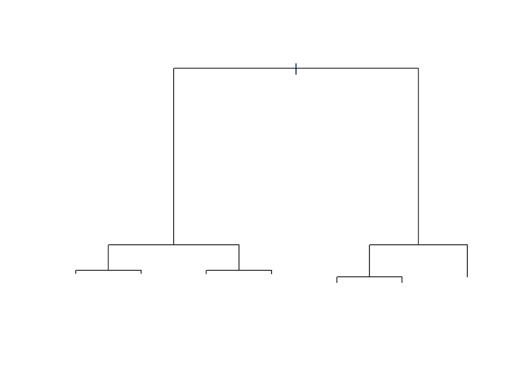

```r
tree <- rpart(full, data=train)
plot(tree)
```

```r
tree.1 <- rpart(best, data=train)
tree.1
```

```
## n= 52508
##
## node), split, n, deviance, yval
##       * denotes terminal node
##
##  1) root 52508 4.511928e+13  27293.660
##    2) Windgeschwindigkeit100MP30< 7.95625 39370 8.073278e+12  14158.900
##      4) Windgeschwindigkeit100MP70< 6.945 24349 1.442773e+12   6302.293 *
##      5) Windgeschwindigkeit100MP70>=6.945 15021 2.691215e+12  26894.440
##       10) Windgeschwindigkeit100MP50< 7.53125 8248 9.130352e+11  21503.540 *
##       11) Windgeschwindigkeit100MP50>=7.53125 6773 1.246574e+12  33459.360 *
##    3) Windgeschwindigkeit100MP30>=7.95625 13138 9.899999e+12  66653.950
##      6) Windgeschwindigkeit100MP40< 10.92 9855 3.699317e+12  55473.490
##       12) Windgeschwindigkeit100MP10< 8.25125 6091 1.520761e+12  48053.990 *
##       13) Windgeschwindigkeit100MP10>=8.25125 3764 1.300657e+12  67479.910 *
##      7) Windgeschwindigkeit100MP40>=10.92 3283 1.270824e+12 100215.800 *
```

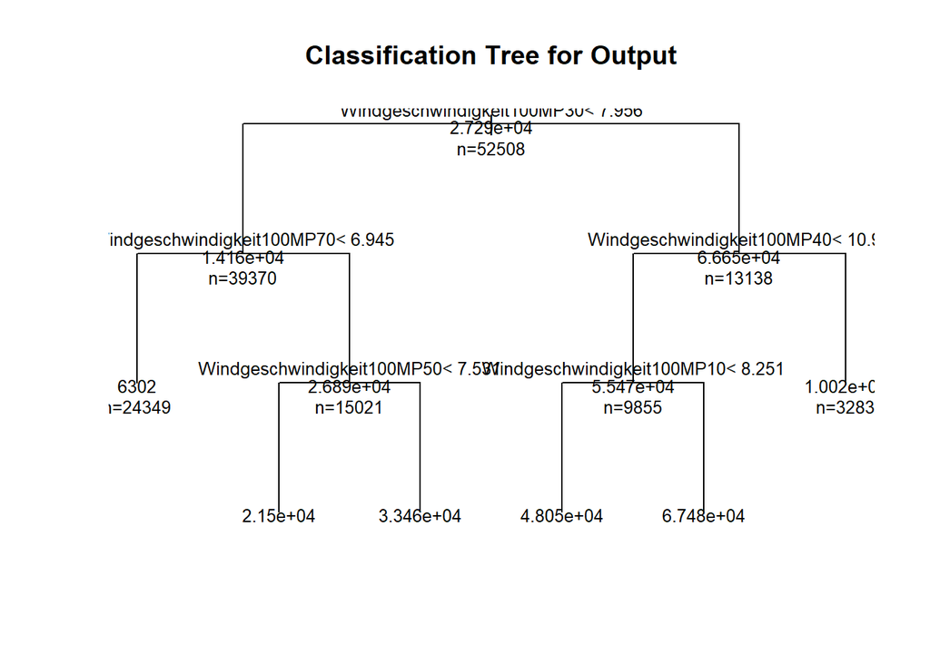

```r
plot(tree.1, uniform=TRUE,
     main="Classification Tree for Output")
text(tree.1, use.n=TRUE, all=TRUE, cex=.8)
```

#### Predictions

```r
#Tree with full formula
print("Full Model Tree")
```

```
## [1] "Full Model Tree"
```

```r
predict.tree <- round(predict(tree, newdata=eval), digits=0)
(sum((eval$Output-predict.tree)^2)/nrow(eval))^(1/2)
```

```
## [1] 14988.81
```

```r
error_tree <- (sum(abs(predict.tree-eval$Output)))/sum(eval$Verfügbare_Kapazität)
error_tree
```

```
## [1] 0.08472233
```

```r
#Tree with Best formula
print("Best Formula Tree")
```

```
## [1] "Best Formula Tree"
```

```r
predict.tree1 <- round(predict(tree.1, newdata=eval), digits=0)
(sum((eval$Output-predict.tree1)^2)/nrow(eval))^(1/2)
```

```
## [1] 15240.88
```

```r
error_tree.1 <- (sum(abs(predict.tree1-eval$Output)))/sum(eval$Verfügbare_Kapazität)
error_tree.1
```

```
## [1] 0.08926338
```

```r
results <- rbind(results, list("Full Formula Tree", error_tree), list("Best Formula Tree", error_tree.1))
```

### Random Forest Models

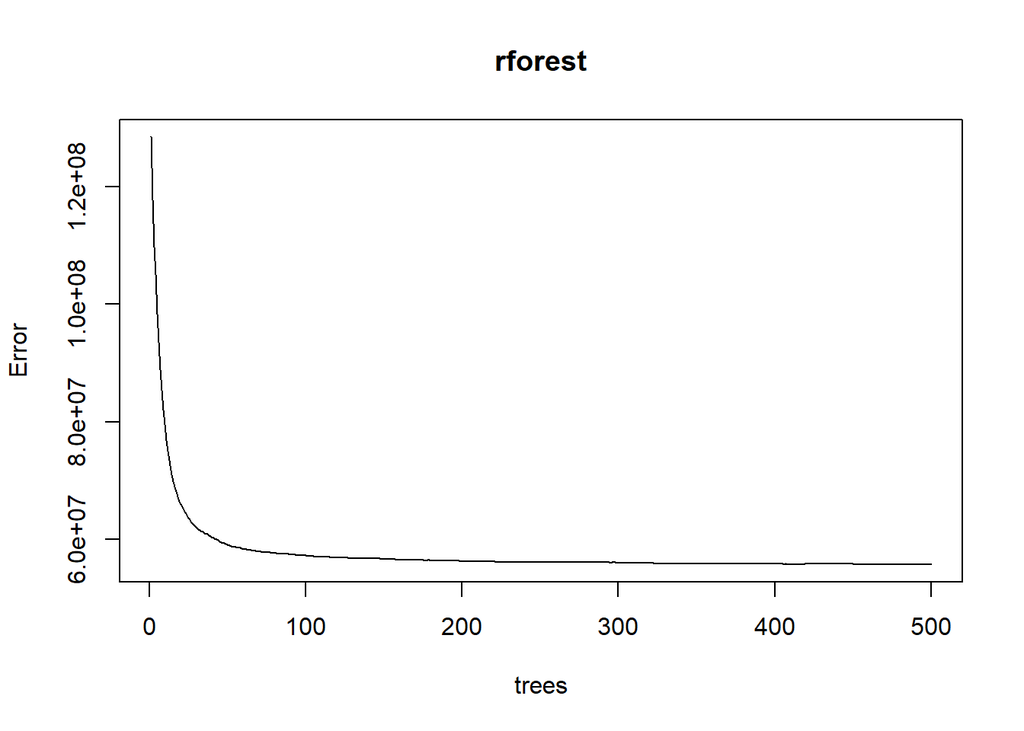

```r
#Full formula model
rforest <- randomForest(Output~., data=train)
plot(rforest)
```

```r
rforest$rsq
```

```
##   [1] 0.8505232 0.8630109 0.8722278 0.8777616 0.8855909 0.8910919 0.8964984
##   [8] 0.9005840 0.9044951 0.9073883 0.9105905 0.9126399 0.9154683 0.9172574
##  [15] 0.9186770 0.9197259 0.9206907 0.9217397 0.9226407 0.9232391 0.9236140
##  [22] 0.9242649 0.9247744 0.9253109 0.9258558 0.9262334 0.9267363 0.9271264
##  [29] 0.9274165 0.9276274 0.9279837 0.9283201 0.9285678 0.9286597 0.9289349
##  [36] 0.9289860 0.9291097 0.9293397 0.9295387 0.9297593 0.9298797 0.9300403
##  [43] 0.9301451 0.9303252 0.9304940 0.9306768 0.9308020 0.9309379 0.9310038
##  [50] 0.9311380 0.9313318 0.9314397 0.9315606 0.9316657 0.9316812 0.9317017
##  [57] 0.9317673 0.9318392 0.9318767 0.9320140 0.9320673 0.9321416 0.9321863
##  [64] 0.9322606 0.9322781 0.9323504 0.9323693 0.9324201 0.9324908 0.9325123
##  [71] 0.9325739 0.9326247 0.9326090 0.9325989 0.9325991 0.9326350 0.9327153
##  [78] 0.9327872 0.9328533 0.9328480 0.9328671 0.9329305 0.9329275 0.9329288
##  [85] 0.9329363 0.9330001 0.9329754 0.9329952 0.9330303 0.9330570 0.9331435
##  [92] 0.9331510 0.9331518 0.9332113 0.9332440 0.9332929 0.9333010 0.9332987
##  [99] 0.9333186 0.9333415 0.9333676 0.9333887 0.9333986 0.9334125 0.9334184
```

[output cut: 57 more lines]

```r
importance(rforest, type=1)
```

```
##
## Datum
## Windgeschwindigkeit48M
## Windgeschwindigkeit100M
## Windgeschwindigkeit152M
## Windrichtung48M
## Windrichtung100M
## Windrichtung152M
## Windgeschwindigkeit100MP10
## Windgeschwindigkeit100MP20
## Windgeschwindigkeit100MP30
## Windgeschwindigkeit100MP40
## Windgeschwindigkeit100MP50
## Windgeschwindigkeit100MP60
## Windgeschwindigkeit100MP70
## Windgeschwindigkeit100MP80
## Windgeschwindigkeit100MP90
## Interpoliert
## Verfügbare_Kapazität
## month
## season
## winddirectionmean
## winddirectionvar
## windspeedmean
## windspeedvar
## winddirectionweightedmean
```

```r
importance(rforest, type=2)
```

```
##                            IncNodePurity
## Datum                       4.346805e+11
## Windgeschwindigkeit48M      5.151736e+11
## Windgeschwindigkeit100M     5.654994e+12
## Windgeschwindigkeit152M     3.811796e+11
## Windrichtung48M             3.485578e+11
## Windrichtung100M            3.185900e+11
## Windrichtung152M            3.715223e+11
## Windgeschwindigkeit100MP10  2.186345e+12
## Windgeschwindigkeit100MP20  6.989337e+12
## Windgeschwindigkeit100MP30  8.082122e+12
## Windgeschwindigkeit100MP40  5.338689e+12
## Windgeschwindigkeit100MP50  4.868758e+12
## Windgeschwindigkeit100MP60  2.626089e+12
## Windgeschwindigkeit100MP70  1.465668e+12
## Windgeschwindigkeit100MP80  1.072027e+12
## Windgeschwindigkeit100MP90  7.749724e+11
## Interpoliert                1.373211e+10
## Verfügbare_Kapazität        2.532614e+11
## month                       2.076377e+11
## season                      9.116521e+10
## winddirectionmean           3.422325e+11
## winddirectionvar            3.706828e+11
## windspeedmean               1.394966e+12
## windspeedvar                4.212632e+11
## winddirectionweightedmean   3.670465e+11
```

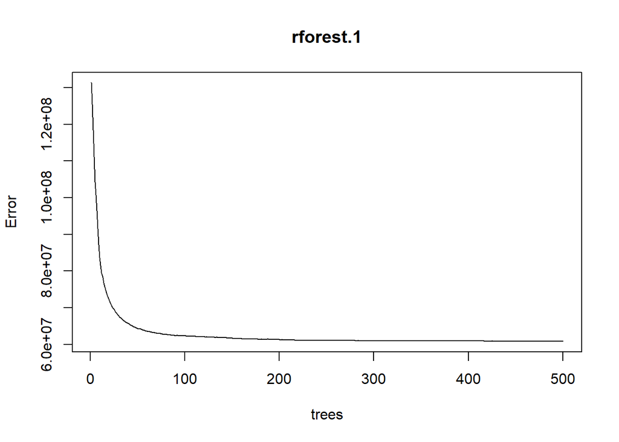

```r
#Best formula Model
rforest.1 <- randomForest(Output~ Datum+Windgeschwindigkeit48M+Windgeschwindigkeit100M+Windgeschwindigkeit152M+Windrichtung48M+Windrichtung100M+Windrichtung152M
                          +Windgeschwindigkeit100MP40+Windgeschwindigkeit100MP50+Windgeschwindigkeit100MP70+Windgeschwindigkeit100MP90+Verfügbare_Kapazität, data=train)
plot(rforest.1)
```

```r
rforest.1$rsq
```

```
##   [1] 0.8471778 0.8539135 0.8622364 0.8706134 0.8786131 0.8827126 0.8877883
##   [8] 0.8934447 0.8985422 0.9025727 0.9051791 0.9074016 0.9089151 0.9107218
##  [15] 0.9117935 0.9127884 0.9138949 0.9148029 0.9155073 0.9162692 0.9169751
##  [22] 0.9175561 0.9183049 0.9186377 0.9189569 0.9194823 0.9199393 0.9202986
##  [29] 0.9207411 0.9210565 0.9214864 0.9218068 0.9219914 0.9223091 0.9225735
##  [36] 0.9228215 0.9230509 0.9232362 0.9233021 0.9235522 0.9237056 0.9239289
##  [43] 0.9240895 0.9242744 0.9244390 0.9246620 0.9247477 0.9248536 0.9249858
##  [50] 0.9250762 0.9251992 0.9252920 0.9253389 0.9254296 0.9255699 0.9256807
##  [57] 0.9257534 0.9258518 0.9260040 0.9260701 0.9261018 0.9262053 0.9262194
##  [64] 0.9262670 0.9263393 0.9263901 0.9264192 0.9264768 0.9265465 0.9266162
##  [71] 0.9267107 0.9267142 0.9267688 0.9267996 0.9268686 0.9269378 0.9269878
##  [78] 0.9270121 0.9270313 0.9270143 0.9270607 0.9271107 0.9270992 0.9271820
##  [85] 0.9272408 0.9272824 0.9273165 0.9273499 0.9273869 0.9274137 0.9273872
##  [92] 0.9273729 0.9274552 0.9274382 0.9274181 0.9274258 0.9274443 0.9274562
##  [99] 0.9274883 0.9275209 0.9275242 0.9275670 0.9275630 0.9275916 0.9275833
```

[output cut: 57 more lines]

#### Predictions

```r
#Full model forest
print("Full Random Forest Model")
```

```
## [1] "Full Random Forest Model"
```

```r
predict.rforest <- round(predict(rforest, newdata=eval), digits=0)
(sum((eval$Output-predict.rforest)^2)/nrow(eval))^(1/2)
```

```
## [1] 14170.53
```

```r
error_rf <- (sum(abs(predict.rforest-eval$Output)))/sum(eval$Verfügbare_Kapazität)
error_rf
```

```
## [1] 0.082277
```

```r
#best model
print("Best Model Formula")
```

```
## [1] "Best Model Formula"
```

```r
predict.rforest1 <- round(predict(rforest.1, newdata=eval), digits=0)
(sum((eval$Output-predict.rforest1)^2)/nrow(eval))^(1/2)
```

```
## [1] 14008.64
```

```r
error_rfbest <- (sum(abs(predict.rforest1-eval$Output)))/sum(eval$Verfügbare_Kapazität)
error_rfbest
```

```
## [1] 0.08110989
```

```r
results <-
  rbind(results,
        list("Full Formula Random Forest",
             error_rf),
        list("Best Formula Random Forest",
             error_rfbest))
```

#### Tuneing the Random Forest Models

```
## mtry = 8  OOB error = 59664953
## Searching left ...
## mtry = 4     OOB error = 63211821
## -0.05944643 0.05
## Searching right ...
## mtry = 16    OOB error = 57662847
## 0.03355581 0.05
```

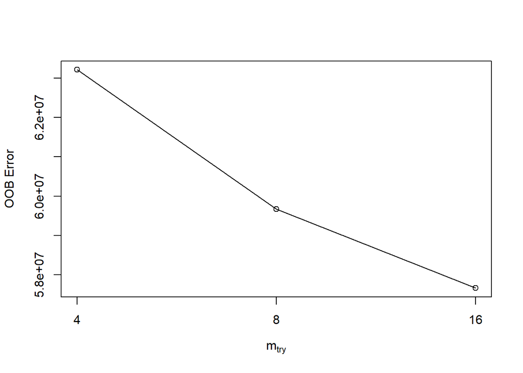

```r
tuned <- tuneRF(train[,-19], train[,19], stepFactor = 2, improve=0.05, plot=TRUE)
```

#### New Tuned Model

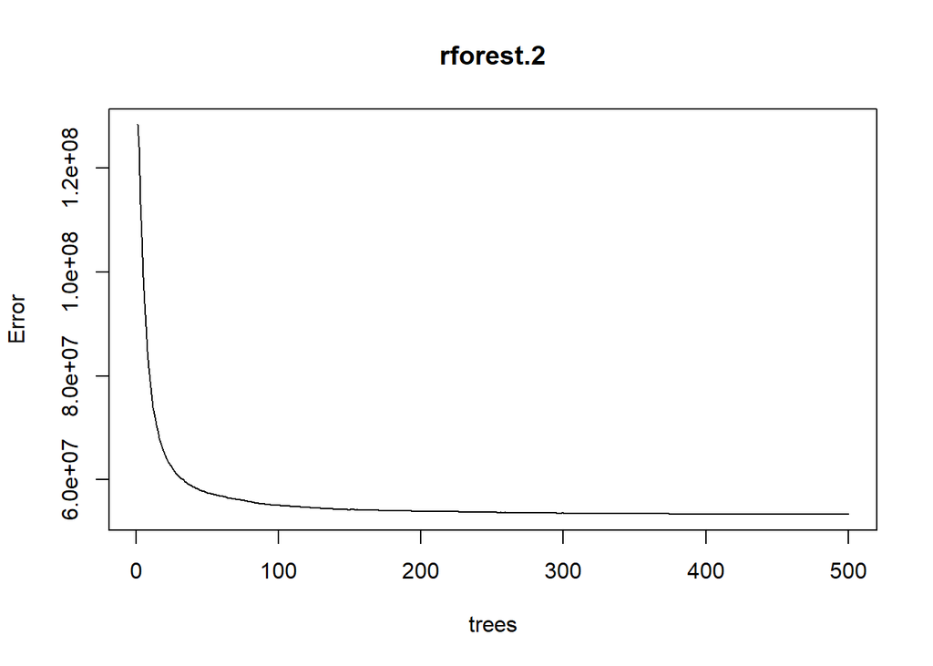

```r
rforest.2 <-
  randomForest(Output~ Datum +
                 Windgeschwindigkeit48M +
                 Windgeschwindigkeit100M +
                 Windgeschwindigkeit152M +
                 Windrichtung100M +
                 Windrichtung152M +
                 Windgeschwindigkeit100MP10+
                 Windgeschwindigkeit100MP30+
                 Windgeschwindigkeit100MP40+
                 Windgeschwindigkeit100MP50+
                 Windgeschwindigkeit100MP70+
                 Windgeschwindigkeit100MP90+
                 Verfügbare_Kapazität +
                 month +
                 winddirectionvar +
                 windspeedvar +
                 winddirectionweightedmean,
               mtry = 8,
               data=train)
plot(rforest.2)
```

#### Predictions

```r
predict.rforest2 <- round(predict(rforest.2, newdata=eval), digits=0)
(sum((eval$Output-predict.rforest2)^2)/nrow(eval))^(1/2)
```

```
## [1] 14094.97
```

```r
error_trf <- (sum(abs(predict.rforest2-eval$Output)))/sum(eval$Verfügbare_Kapazität)
error_trf
```

```
## [1] 0.08196011
```

```r
results <-
  rbind(results,
        list("Tuned Random Forest",
             error_trf))
```

#### PLots

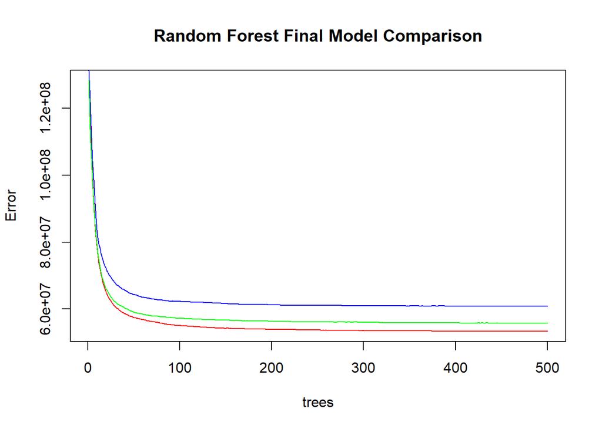

```r
plot(rforest.2, col = "red", main = "Random Forest Final Model Comparison")
plot(rforest.1, col= "blue", add= TRUE)
plot(rforest, col = "green", add= TRUE)
```

### Bagged Model

```r
#full formula model
bag <- bagging(train$Output~., train)

#best formula model
bag.1 <-
  bagging(Output~ Datum +
            Windgeschwindigkeit48M +
            Windgeschwindigkeit100M +
            Windgeschwindigkeit152M +
            Windrichtung100M +
            Windrichtung152M +
            Windgeschwindigkeit100MP10 +
            Windgeschwindigkeit100MP30 +
            Windgeschwindigkeit100MP40 +
            Windgeschwindigkeit100MP50 +
            Windgeschwindigkeit100MP70 +
            Windgeschwindigkeit100MP90 +
            Verfügbare_Kapazität +
            month +
            winddirectionvar +
            windspeedvar +
            winddirectionweightedmean,
          data=train)
```

#### Predictions

```r
#full model preds
print("Full Model")
```

```
## [1] "Full Model"
```

```r
predict.bag <- round(predict(bag, newdata=eval),digits=0)
(sum((eval$Output-predict.bag)^2)/nrow(eval))^(1/2)
```

```
## [1] 14643.73
```

```r
error_bag <- (sum(abs(predict.bag-eval$Output)))/sum(eval$Verfügbare_Kapazität)
error_bag
```

```
## [1] 0.08469099
```

```r
#best model preds
print("Best Model")
```

```
## [1] "Best Model"
```

```r
predict.bag1 <- round(predict(bag.1, newdata = eval), digits=0)
(sum((eval$Output-predict.bag1)^2)/nrow(eval))^(1/2)
```

```
## [1] 14662.09
```

```r
error_bagbest <- (sum(abs(predict.bag1-eval$Output)))/sum(eval$Verfügbare_Kapazität)
error_bagbest
```

```
## [1] 0.0844946
```

```r
results <-
  rbind(results,
        list("Full Formula Bagging Model",
             error_bag),
        list("Best Formula Bagging Model",
             error_bagbest))
```

### Gradient Boosting Model

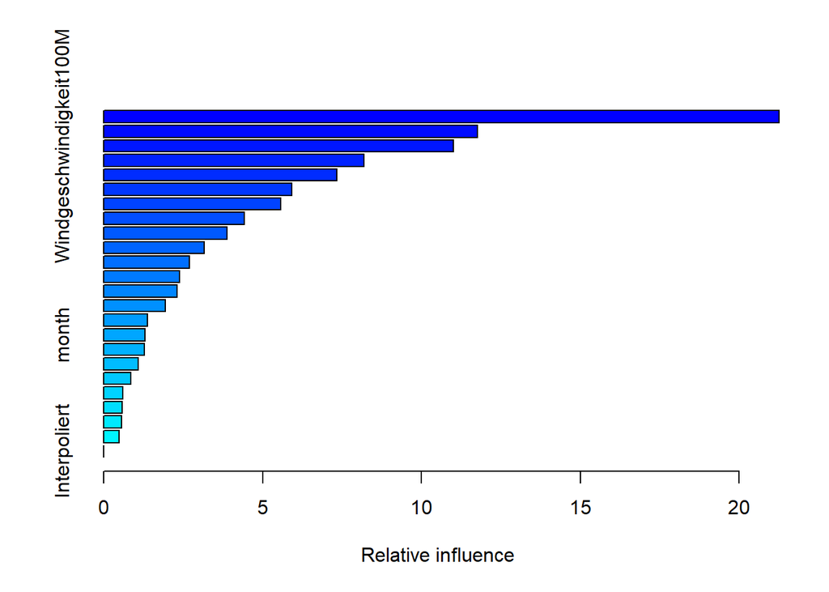

```
##                                                   var      rel.inf
## Windgeschwindigkeit100MP90 Windgeschwindigkeit100MP90 2.124980e+01
## Windgeschwindigkeit48M         Windgeschwindigkeit48M 1.176443e+01
## Windgeschwindigkeit100M       Windgeschwindigkeit100M 1.100909e+01
## Windgeschwindigkeit100MP50 Windgeschwindigkeit100MP50 8.186842e+00
## Windgeschwindigkeit100MP80 Windgeschwindigkeit100MP80 7.342411e+00
## Windgeschwindigkeit100MP30 Windgeschwindigkeit100MP30 5.915902e+00
## Windgeschwindigkeit100MP70 Windgeschwindigkeit100MP70 5.562617e+00
## Windgeschwindigkeit100MP20 Windgeschwindigkeit100MP20 4.420381e+00
## windspeedmean                           windspeedmean 3.890804e+00
## Windgeschwindigkeit100MP40 Windgeschwindigkeit100MP40 3.164325e+00
## Windgeschwindigkeit152M       Windgeschwindigkeit152M 2.698008e+00
## Windgeschwindigkeit100MP10 Windgeschwindigkeit100MP10 2.387587e+00
## Windgeschwindigkeit100MP60 Windgeschwindigkeit100MP60 2.312658e+00
## Windrichtung152M                     Windrichtung152M 1.938799e+00
## winddirectionvar                     winddirectionvar 1.374704e+00
## month                                           month 1.301944e+00
## Windrichtung48M                       Windrichtung48M 1.288467e+00
## windspeedvar                             windspeedvar 1.098189e+00
## winddirectionweightedmean   winddirectionweightedmean 8.612906e-01
## winddirectionmean                   winddirectionmean 5.969787e-01
## Verfügbare_Kapazität             Verfügbare_Kapazität 5.801938e-01
## Windrichtung100M                     Windrichtung100M 5.699715e-01
## season                                         season 4.839320e-01
## Interpoliert                             Interpoliert 6.739116e-04
```

```r
#full model
boost <-
  gbm(Output~.-Datum,
      distribution = "laplace",
      data=train, n.trees = 1000,
      shrinkage = 0.03,
      interaction.depth = 6)
summary(boost)
```

```r
#fewer trees
boost.fewtrees <- gbm(Output~.-Datum,
                      data=train,
                      n.trees = 700,
                      shrinkage = 0.01,
                      interaction.depth = 8)
```

```
## Distribution not specified, assuming gaussian ...
```

```r
#600 trees
boost.600 <- gbm(Output~.-Datum,
                 data=train,
                 n.trees = 600,
                 shrinkage = 0.01,
                 interaction.depth = 8)
```

```
## Distribution not specified, assuming gaussian ...
```

```r
#no date
boost.1 <-
  gbm(Output ~ Windgeschwindigkeit48M +
        Windgeschwindigkeit100M +
        Windgeschwindigkeit152M +
        Windrichtung48M +
        Windrichtung100M +
        Windrichtung152M +
        Windgeschwindigkeit100MP40 +
        Windgeschwindigkeit100MP50 +
        Windgeschwindigkeit100MP70 +
        Windgeschwindigkeit100MP90 +
        Verfügbare_Kapazität,
      data = train,
      distribution = "laplace",
      n.trees = 1000,
      shrinkage = 0.03,
      interaction.depth = 7)

#new var boost
boost.12 <-
  gbm(Output~Windgeschwindigkeit48M +
        Windgeschwindigkeit100M +
        Windgeschwindigkeit152M +
        Windrichtung100M +
        Windrichtung152M +
        Windgeschwindigkeit100MP10 +
        Windgeschwindigkeit100MP30 +
        Windgeschwindigkeit100MP40 +
        Windgeschwindigkeit100MP50 +
        Windgeschwindigkeit100MP70 +
        Windgeschwindigkeit100MP90 +
        Verfügbare_Kapazität +
        month +
        winddirectionvar +
        windspeedvar +
        winddirectionweightedmean,
      data=train,
      distribution = "laplace",
      n.trees = 700,
      shrinkage = 0.03,
      interaction.depth = 6)
```

#### Predictions

```r
#full model preds
print("Full Model")
```

```
## [1] "Full Model"
```

```r
predict.boost <- round(predict(boost, newdata=eval, n.trees = 1000), digits=0)
(sum((eval$Output-predict.boost)^2)/nrow(eval))^(1/2)
```

```
## [1] 13502.22
```

```r
error_grad <- (sum(abs(predict.boost-eval$Output)))/sum(eval$Verfügbare_Kapazität)
error_grad
```

```
## [1] 0.07405455
```

```r
#few trees
print("Fewer Trees")
```

```
## [1] "Fewer Trees"
```

```r
predict.boostft <- round(predict(boost.fewtrees, newdata=eval, n.trees = 700), digits=0)
(sum((eval$Output-predict.boostft)^2)/nrow(eval))^(1/2)
```

```
## [1] 13509.82
```

```r
error_gradFT <- (sum(abs(predict.boostft-eval$Output)))/sum(eval$Verfügbare_Kapazität)
error_gradFT
```

```
## [1] 0.07617576
```

```r
#600 Trees
print("600 Trees")
```

```
## [1] "600 Trees"
```

```r
predict.boost600 <- round(predict(boost.600, newdata=eval, n.trees = 600), digits=0)
(sum((eval$Output-predict.boost600)^2)/nrow(eval))^(1/2)
```

```
## [1] 13497.57
```

```r
error_g600 <- (sum(abs(predict.boost600-eval$Output)))/sum(eval$Verfügbare_Kapazität)
error_g600
```

```
## [1] 0.07616309
```

```r
#no date
print("No Date Model")
```

```
## [1] "No Date Model"
```

```r
predict.boost1 <- round(predict(boost.1, newdata=eval, n.trees = 1000), digits=0)
(sum((eval$Output-predict.boost1)^2)/nrow(eval))^(1/2)
```

```
## [1] 13455.36
```

```r
error_gnd <- (sum(abs(predict.boost1-eval$Output)))/sum(eval$Verfügbare_Kapazität)
error_gnd
```

```
## [1] 0.07331792
```

```r
#new var boost
print("New Variable Model")
```

```
## [1] "New Variable Model"
```

```r
predict.boost12 <- round(predict(boost.12, newdata=eval, n.trees = 700), digits=0)
error_gdbNV <- (sum(abs(predict.boost12-eval$Output)))/sum(eval$Verfügbare_Kapazität)
error_gdbNV
```

```
## [1] 0.07383893
```

```r
results <-
  rbind(results,
        list("Full Formula Gradient Boosting Model",
             error_grad),
        list("Fewer Trees GBM",
             error_gradFT),
        list("600 Trees GBM",
             error_g600),
        list("GBM Without Date",
             error_gnd),
        list("New Variable GBM",
             error_gdbNV))
```

The gradient boosting models have preformed the best overall at predicting the validation set. As such, I’ll be creating notably more of these models, for tuning and further testing.

```r
#decreasing shrinkage rate
boost.2 <-
  gbm(Output~Windgeschwindigkeit48M +
        Windgeschwindigkeit100M +
        Windgeschwindigkeit152M +
        Windrichtung48M +
        Windrichtung100M +
        Windrichtung152M +
        Windgeschwindigkeit100MP40 +
        Windgeschwindigkeit100MP50 +
        Windgeschwindigkeit100MP70 +
        Windgeschwindigkeit100MP90 +
        Verfügbare_Kapazität,
      data=train,
      n.trees = 600,
      shrinkage = 0.02,
      interaction.depth = 8)
```

```
## Distribution not specified, assuming gaussian ...
```

```r
boost.3 <-
  gbm(Output~ Windgeschwindigkeit48M +
        Windgeschwindigkeit100M +
        Windgeschwindigkeit152M +
        Windrichtung48M +
        Windrichtung100M +
        Windrichtung152M +
        Windgeschwindigkeit100MP40 +
        Windgeschwindigkeit100MP50 +
        Windgeschwindigkeit100MP70 +
        Windgeschwindigkeit100MP90 +
        Verfügbare_Kapazität,
      data=train,
      n.trees = 600,
      shrinkage = 0.03,
      interaction.depth = 8)
```

```
## Distribution not specified, assuming gaussian ...
```

```r
class(train$month)
```

```
## [1] "numeric"
```

```r
train$month <- as.factor(train$month)
boost.fac <-
  gbm(Output~ month +
        Windgeschwindigkeit48M +
        Windgeschwindigkeit100M +
        Windgeschwindigkeit152M +
        Windrichtung48M +
        Windrichtung100M +
        Windrichtung152M +
        Windgeschwindigkeit100MP40 +
        Windgeschwindigkeit100MP50 +
        Windgeschwindigkeit100MP70 +
        Windgeschwindigkeit100MP90 +
        Verfügbare_Kapazität,
      distribution = "laplace",
      data=train,
      n.trees = 600,
      shrinkage = 0.03,
      interaction.depth = 7)
train$month <- as.numeric(train$month)
```

#### Predictions

```r
predict.boost2 <- round(predict(boost.2, newdata=eval, n.trees = 600), digits=0)
error_gbm.2 <- (sum(abs(predict.boost2-eval$Output)))/sum(eval$Verfügbare_Kapazität)
error_gbm.2
```

```
## [1] 0.07536679
```

```r
predict.boost3 <- round(predict(boost.3, newdata=eval, n.trees = 600), digits=0)
error_gbm.3 <- (sum(abs(predict.boost3-eval$Output)))/sum(eval$Verfügbare_Kapazität)
error_gbm.3
```

```
## [1] 0.07563748
```

```r
eval$month <- as.factor(eval$month)
predict.boost.fac <- round(predict(boost.fac, newdata=eval, n.trees = 600), digits=0)
error_gbm.fac <- (sum(abs(predict.boost.fac-eval$Output)))/sum(eval$Verfügbare_Kapazität)
error_gbm.fac
```

```
## [1] 0.07364957
```

```r
eval$month <- as.numeric(eval$month)

results <-
  rbind(results,
        list("Decrease Shrinkage Boost",
             error_gbm.2),
        list("Gaussian GBM", error_gbm.3),
        list("Factor Month GBM",
             error_gbm.fac))
```

### General Additive Model (GAM)

```r
#model 1
gam_form <- as.formula(paste("Output~ month+s(Windgeschwindigkeit48M)+s(Windgeschwindigkeit100M)+s(Windgeschwindigkeit152M)+s(Windrichtung48M)+s(Windrichtung100M)+s(Windrichtung152M)+s(Windgeschwindigkeit100MP40)+s(Windgeschwindigkeit100MP50)+s(Windgeschwindigkeit100MP70)+s(Windgeschwindigkeit100MP90)+s(Verfügbare_Kapazität)"))

gam1 <- gam(formula = gam_form,
            family=gaussian, data=train)
#model 2
gam_formsix <- as.formula(paste("Output~ s(Windgeschwindigkeit48M)+s(Windgeschwindigkeit100M)+s(Windgeschwindigkeit152M)+s(Windrichtung48M)+s(Windrichtung100M)+s(Windrichtung152M)+s(Windgeschwindigkeit100MP10)+s(Windgeschwindigkeit100MP20)+s(Windgeschwindigkeit100MP50)+s(Windgeschwindigkeit100MP60)+s(Windgeschwindigkeit100MP80)+s(Verfügbare_Kapazität)+ s(winddirectionweightedmean)+s(windspeedmean)"))
gam2 <- gam(formula = gam_formsix,
             family=gaussian, data=train)
```

#### Predictions

```r
#Model 1
print("Model 1")
```

```
## [1] "Model 1"
```

```r
predict.gam <- round(predict(gam1, newdata=eval), digits=0)
error_gam1 <- (sum(abs(predict.gam-eval$Output)))/sum(eval$Verfügbare_Kapazität)
error_gam1
```

```
## [1] 0.07693651
```

```r
#Model 2
print("Model 2")
```

```
## [1] "Model 2"
```

```r
predict.gam2 <- round(predict(gam2, newdata=eval), digits=0)
error_gam2 <- (sum(abs(predict.gam2-eval$Output)))/sum(eval$Verfügbare_Kapazität)
error_gam2
```

```
## [1] 0.07708005
```

```r
results <-
  rbind(results,
        list("GAM Model 1", error_gam1),
        list("GAM Model 2", error_gam2))
```

## Matching The Dates

The data presented as the training data covers significant period of time, but the “challenge” was to predict the output for a much shorter range of time in the following year. It may be that, due to some seasonality (which would make sense as this is highly dependant on the weather) may be causing us to over or underestimate in our predictions. As such, I am going to restrict the training data set to dates which match those in the validation set.

```r
summary(train$Datum) #2016 Jan - 2017 June
```

```
##         Min.      1st Qu.       Median         Mean      3rd Qu.         Max.
## "2016-01-01" "2016-05-16" "2016-09-30" "2016-09-30" "2017-02-14" "2017-06-30"
```

```r
summary(eval$Datum) #2017 July - 2017 Dec
```

```
##         Min.      1st Qu.       Median         Mean      3rd Qu.         Max.
## "2017-07-01" "2017-08-16" "2017-10-01" "2017-09-30" "2017-11-15" "2017-12-31"
```

```r
train.dates <- subset.data.frame(train, Datum >= "2016-07-01" & Datum <= "2016-12-31")
```

### Gradient Boosting on Matching Date Data

I’ll start by using the best preforming model from the full training data set.

```r
boost.Dates.1 <-
  gbm(Output ~ Windgeschwindigkeit48M +
        Windgeschwindigkeit100M +
        Windgeschwindigkeit152M +
        Windrichtung48M +
        Windrichtung100M +
        Windrichtung152M +
        Windgeschwindigkeit100MP40 +
        Windgeschwindigkeit100MP50 +
        Windgeschwindigkeit100MP70 +
        Windgeschwindigkeit100MP90 +
        Verfügbare_Kapazität,
      data = train.dates,
      distribution = "laplace",
      n.trees = 1000,
      shrinkage = 0.03,
      interaction.depth = 7)

boost.Dates.2 <-
  gbm(Output~Windgeschwindigkeit48M +
        Windgeschwindigkeit100M +
        Windgeschwindigkeit152M +
        Windrichtung100M +
        Windrichtung152M +
        Windgeschwindigkeit100MP10 +
        Windgeschwindigkeit100MP30 +
        Windgeschwindigkeit100MP40 +
        Windgeschwindigkeit100MP50 +
        Windgeschwindigkeit100MP70 +
        Windgeschwindigkeit100MP90 +
        Verfügbare_Kapazität +
        month +
        winddirectionvar +
        windspeedvar +
        winddirectionweightedmean,
      data=train.dates,
      distribution = "laplace",
      n.trees = 700,
      shrinkage = 0.03,
      interaction.depth = 6)
```

```r
print("No Date Model")
```

```
## [1] "No Date Model"
```

```r
predict.boost.Dates.1 <- round(predict(boost.Dates.1, newdata=eval, n.trees = 1000), digits=0)
(sum((eval$Output-predict.boost.Dates.1)^2)/nrow(eval))^(1/2)
```

```
## [1] 13483.99
```

```r
error_gbm.d.1 <- (sum(abs(predict.boost.Dates.1-eval$Output)))/sum(eval$Verfügbare_Kapazität)
error_gbm.d.1
```

```
## [1] 0.07405681
```

```r
predict.boost.Dates.2 <- round(predict(boost.Dates.2, newdata=eval, n.trees = 700), digits=0)
(sum((eval$Output-predict.boost.Dates.2)^2)/nrow(eval))^(1/2)
```

```
## [1] 13612.99
```

```r
error_gbm.d.2 <- (sum(abs(predict.boost.Dates.2-eval$Output)))/sum(eval$Verfügbare_Kapazität)
error_gbm.d.2
```

```
## [1] 0.07521759
```

```r
results <-
  rbind(results,
        list("GBM No Date - Matching Date Data", error_gbm.d.1),
        list("GBM New Var - Matching Dates", error_gbm.d.2))
```

### GAM Dates Models

```r
#model 1
gam1.dates <- gam(formula = gam_form,
            family=gaussian,
            data=train.dates)
#model 2
gam2.dates <- gam(formula = gam_formsix,
             family=gaussian,
             data=train.dates)
```

#### Predictions

```r
#Model 1
print("Model 1")
```

```
## [1] "Model 1"
```

```r
predict.gam1.dates <-
  round(predict(gam1.dates, newdata=eval),
        digits=0)
error_gam1.dates <- (sum(abs(predict.gam1.dates-eval$Output)))/sum(eval$Verfügbare_Kapazität)
error_gam1.dates
```

```
## [1] 0.09570509
```

```r
#Model 2
print("Model 2")
```

```
## [1] "Model 2"
```

```r
predict.gam2.dates <-
  round(predict(gam2.dates, newdata=eval),
        digits=0)
error_gam2.dates <- (sum(abs(predict.gam2.dates-eval$Output)))/sum(eval$Verfügbare_Kapazität)
error_gam2.dates
```

```
## [1] 0.07861252
```

```r
results <-
  rbind(results,
        list("GAM 1 - Matching Dates",
             error_gam1.dates),
        list("GAM 2 - Matching Dates",
             error_gam2.dates))
```

### RF Dates Models

```r
rforest.dates <- randomForest(Output~., data=train.dates)
```

#### Predictions

```r
print("RF Dates")
```

```
## [1] "RF Dates"
```

```r
predict.rf.dates <-
  round(predict(rforest.dates, newdata=eval),
        digits=0)
error_rf.dates <- (sum(abs(predict.rf.dates-eval$Output)))/sum(eval$Verfügbare_Kapazität)
error_rf.dates
```

```
## [1] 0.08628309
```

```r
results <-
  rbind(results,
        list("RF Dates",
             error_rf.dates))
```

## Saving Results Data

```r
save(results, file = "Data_out/results.Rda")
```